# How to get GitHub Copilot

A step-by-step guide

If you have any trouble with the installation, you can also get help and instructions in the [GitHub Copilot Docs](https://docs.github.com/en/copilot).

## 1. Create a GitHub account

You can get one [here](https://github.com/signup). If you want to have an educational account (see step 2), you need to register with your university email address or add it to your account in addition to your private email address.

To add a second email address to your account, go to your profile settings and click on `Emails` in the left sidebar. Then click on `Add email address` and follow the instructions.

Add a billing address in the [`Billing and plans` section](https://github.com/settings/billing/payment_information) of your profile settings. You will not be charged for GitHub Copilot, but you need to have a billing address to get it.

## 2. Apply for an educational account

You can apply for an educational account [here](https://education.github.com/discount_requests/application). You can verify your academic status e.g. by uploading

- your immatriculation certificate
- a letter with the university letterhead stating your academic affiliation

It will take up to a few days to grant you your educational account. Every few years or so, they will ask you to re-verify your academic status.

## 3. Subscribe GitHub Copilot

When you have the educational account, you are eligible to get GitHub Copilot for free. You can check if it worked, by going to your [GitHub profile settings on](https://github.com/settings/billing/summary), click on `Billing and plans/Plans and usage` in the left sidebar. Scroll down to the Section Add-ons. You should see something like this:

[figure not shown]

Eligible for free Copilot

To subscribe to GitHub Copilot, go to the to the [GitHub Copilot settings](https://github.com/settings/copilot) on your GitHub profile and find the subscribe button.

Alternatively, you can subscribe via the [Copilot website](https://github.com/features/copilot/plans). Chose the “individual” plan for 10$ per month and follow the instructions. If you have an educational account you will get it for free.

## 4. Check Copilot settings

Once you have a Copilot subscription, check the policy settings and change them. Go to your Github profile settings and click on `Copilot` in the left sidebar. Then find the `Policy` section. I recommend the following settings:

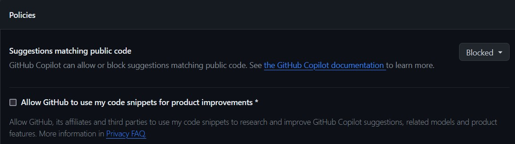

Copilot settings

## 5. Install and configure an IDE that supports Copilot

### Positron

- [Download Positron](https://positron.posit.co/download.html)
- [Setup guide for GitHub Copilot in Positron](https://positron.posit.co/assistant-getting-started.html)

### Visual Studio Code

- Download and install [Visual Studio Code](https://code.visualstudio.com/Download)
- Install [GitHub Copilot VS Code extension](https://docs.github.com/en/copilot/using-github-copilot/getting-started-with-github-copilot?tool=vscode#installing-the-github-copilot-extension-in-visual-studio-code)
- Install [GitHub Copilot Chat](https://docs.github.com/en/copilot/github-copilot-chat/using-github-copilot-chat-in-your-ide#installing-the-github-copilot-chat-extension-in-visual-studio-code)

### R Studio

- Download and install [R Studio](https://posit.co/downloads/)
- Connect and configure [GitHub Copilot for R Studio](https://docs.posit.co/ide/user/ide/guide/tools/copilot.html#setup)